# Doing Data Science Case Study 2

Joshua Yi & Grant Bourzikas

November 24, 2018

### **Introduction**

Yi & Bourzikas specializes in talent management solutions for Fortune 1000 companies focus on building and developing strategies for retaining employees. We specialize in workforce planning, employee training programs, identifying high-potential employees and reducing/preventing voluntary employee turnover (attrition). As part of this engagement, our data science team will predict for your organization.

```
##  [1] "ID"                               "Age"
##  [3] "DailyRate"                        "DistanceFromHome"
##  [5] "Education"                        "EmployeeCount"
##  [7] "EnvironmentSatisfaction"          "HourlyRate"
##  [9] "JobInvolvement"                   "JobSatisfaction"
## [11] "MonthlyIncome"                    "MonthlyRate"
## [13] "NumCompaniesWorked"               "PercentSalaryHike"
## [15] "PerformanceRating"                "RelationshipSatisfaction"
## [17] "StandardHours"                    "StockOptionLevel"
## [19] "TotalWorkingYears"                "TrainingTimesLastYear"
## [21] "WorkLifeBalance"                  "YearsAtCompany"
## [23] "YearsInCurrentRole"               "YearsSinceLastPromotion"
## [25] "YearsWithCurrManager"             "BusinessTravel_Travel_Rarely"
## [27] "BusinessTravel_Travel_Frequently" "BusinessTravel_Non-Travel"
## [29] "Gender_Female"                    "Gender_Male"
## [31] "MaritalStatus_Married"            "MaritalStatus_Divorced"
## [33] "MaritalStatus_Single"             "Over18_Y"
## [35] "OverTime_No"                      "OverTime_Yes"
```

We received the data files from your employee database and have outlined some key highlights. The following charts are part of our exploratory data and will give your organization an idea of how different features in the data set apply. The pair plots show all the variables based on whether your employees have left the organisation.

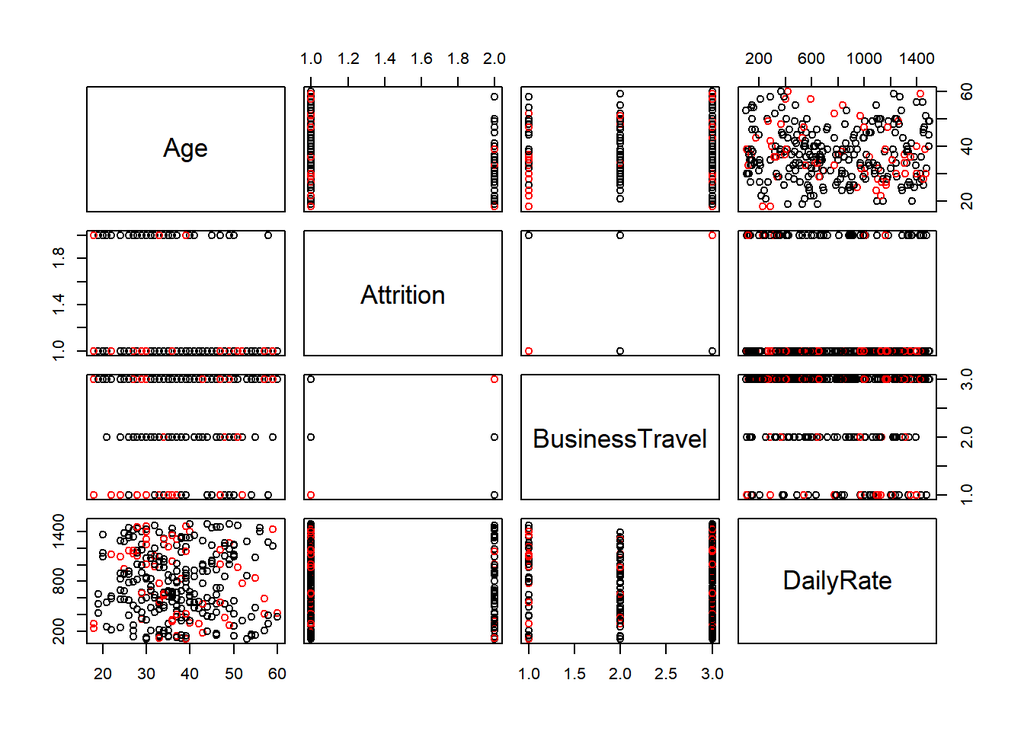

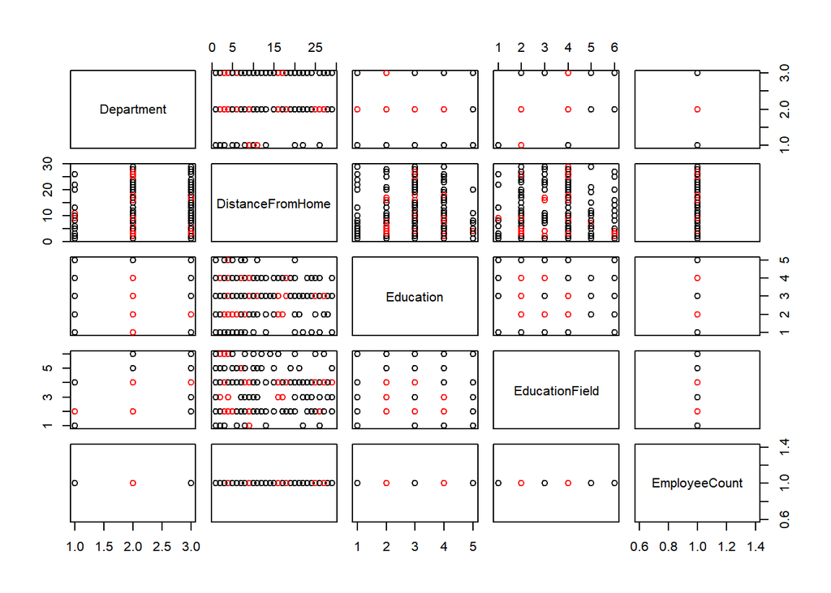

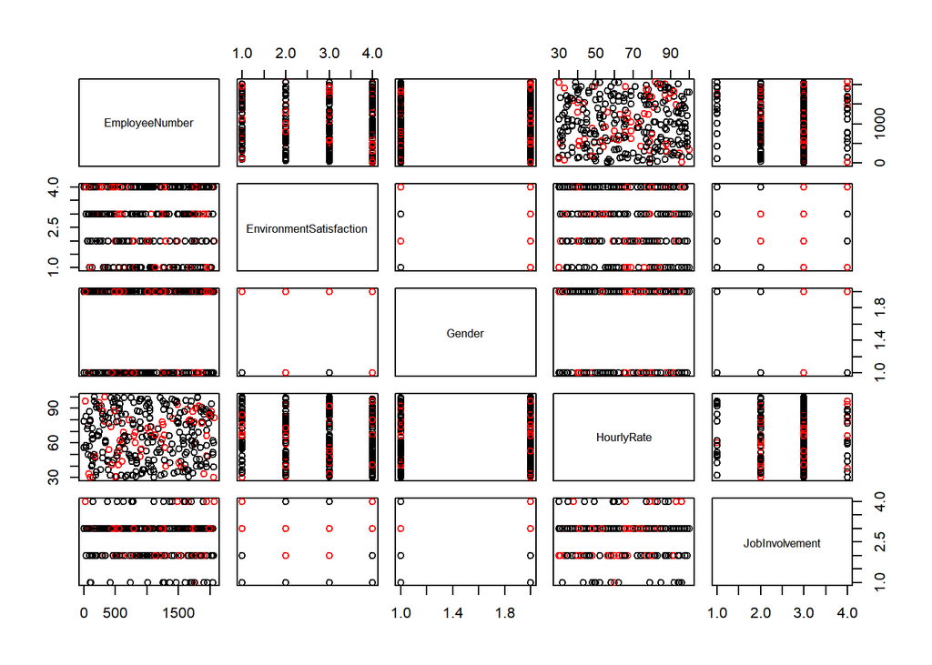

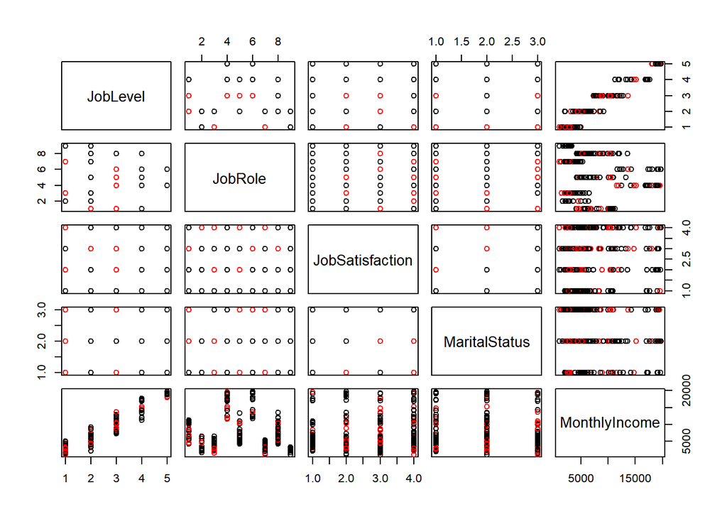

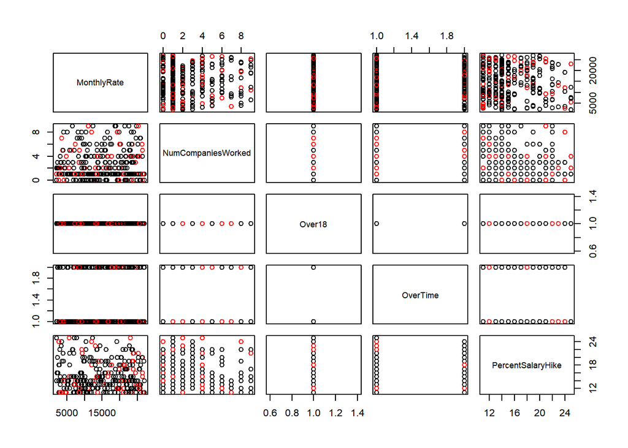

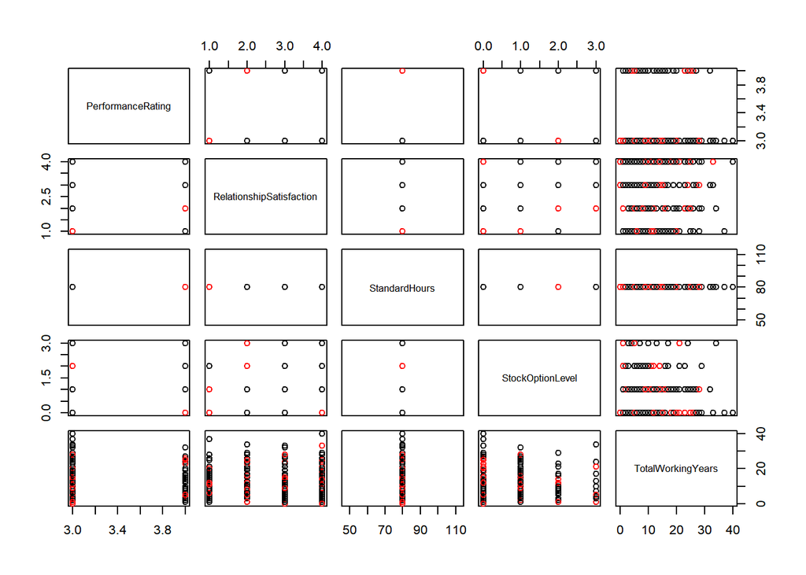

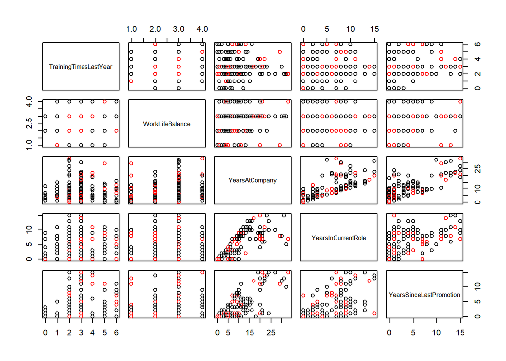

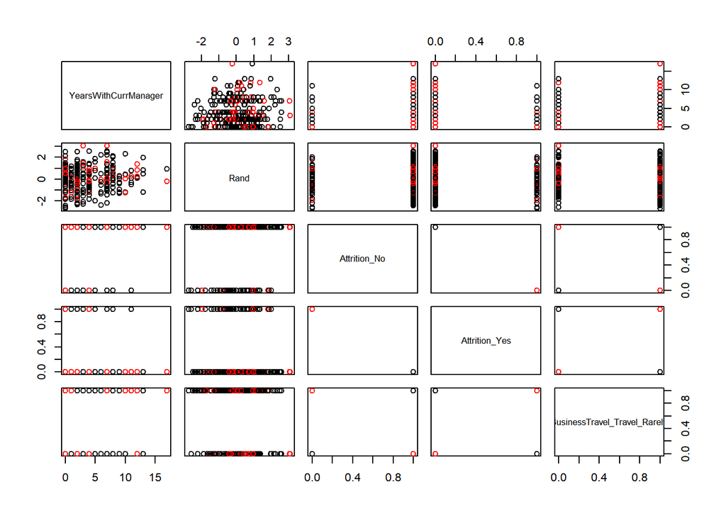

#### *Heat Map Charts*

Because of the data that we were able to analyze as part of the Par Plots above, we developed 2 Heat Maps and Correlations and Distribution Matrix to take a deeper dive in the data set.

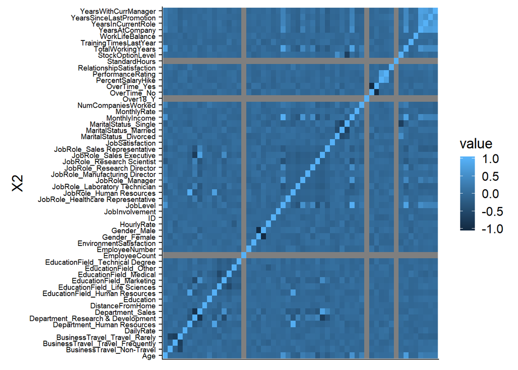

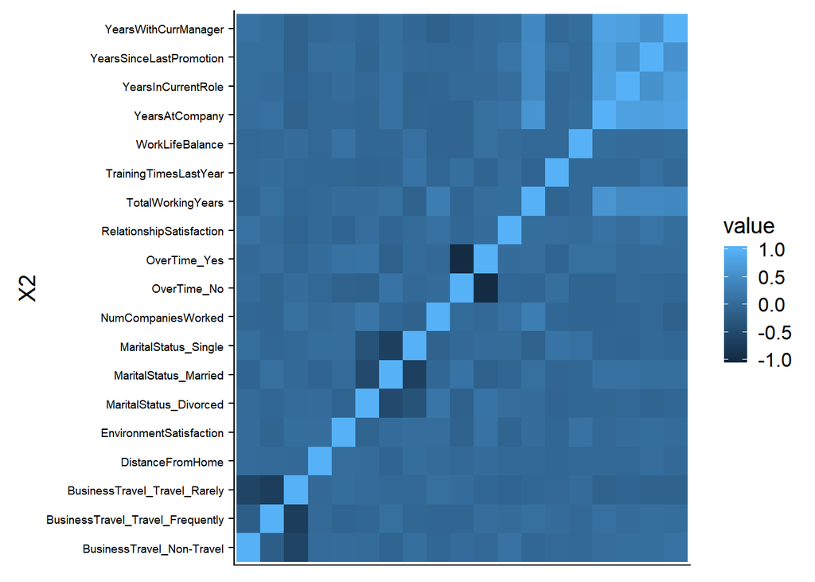

#### *Signficant Key Factor attributing to Attirtion*

Showing the significance, p-values, for each variable. This is the base information to understand the key contributors that affect attrition. This data will be used through our data science work so we can utilize the following variables for the models we build.

The following table outlines the top significant factors contributing to attrition:

|  | Logistic Regression on Training Set |
| --- | --- |
| (Intercept) | 0.9856239 |
| ID | 0.7413226 |
| Age | 0.2081840 |
| BusinessTravelTravel_Frequently | 0.0000674 |
| BusinessTravelTravel_Rarely | 0.0257045 |
| DailyRate | 0.1137743 |
| DepartmentResearch & Development | 0.9840834 |
| DepartmentSales | 0.9855939 |
| DistanceFromHome | 0.0003241 |
| Education | 0.8266214 |
| EducationFieldLife Sciences | 0.9750329 |
| EducationFieldMarketing | 0.8437994 |
| EducationFieldMedical | 0.9098803 |
| EducationFieldOther | 0.6960025 |
| EducationFieldTechnical Degree | 0.4683605 |
| EmployeeNumber | 0.9027209 |
| EnvironmentSatisfaction | 0.0000007 |
| GenderMale | 0.0660375 |
| HourlyRate | 0.2337414 |
| JobInvolvement | 0.0000060 |
| JobLevel | 0.3421974 |
| JobRoleHuman Resources | 0.9829785 |
| JobRoleLaboratory Technician | 0.0127075 |
| JobRoleManager | 0.8653399 |
| JobRoleManufacturing Director | 0.8918567 |
| JobRoleResearch Director | 0.0349614 |
| JobRoleResearch Scientist | 0.8565130 |
| JobRoleSales Executive | 0.1372067 |
| JobRoleSales Representative | 0.0299926 |
| JobSatisfaction | 0.0000192 |
| MaritalStatusMarried | 0.0601860 |
| MaritalStatusSingle | 0.0008135 |
| MonthlyIncome | 0.2085435 |
| MonthlyRate | 0.4484720 |
| NumCompaniesWorked | 0.0000051 |
| OverTimeYes | 0.0000000 |
| PercentSalaryHike | 0.6585720 |
| PerformanceRating | 0.7420886 |
| RelationshipSatisfaction | 0.0363799 |
| StockOptionLevel | 0.2540503 |
| TotalWorkingYears | 0.0141019 |
| TrainingTimesLastYear | 0.0335913 |
| WorkLifeBalance | 0.0006481 |
| YearsAtCompany | 0.0107927 |
| YearsInCurrentRole | 0.0034318 |
| YearsSinceLastPromotion | 0.0000925 |
| YearsWithCurrManager | 0.0131109 |

#### *Basic Regrewssion for each Job Role*

Learning about any job role specific trends that may exist in the data set is key because it tells us which variables are significant by job. This data can be used to identify what affects will contribute to attrition rate by job. Any value that is < 0.5 is significant

From the tables below, each job description will show the key attributes for attrition:

|  | Human Resources | Manufacturing Director | Research Scientist | Laboratory Technician | Research Director | Sales Executive | Manager |
| --- | --- | --- | --- | --- | --- | --- | --- |
| (Intercept) | 0.9898902 | 0.8562672 | 0.0105992 | 0.7634204 | 0.9978978 | 0.0476180 | 0.9978271 |
| ID | 0.7800491 | 0.0850500 | 0.0037740 | 0.3127304 | 0.9980976 | 0.1538642 | 0.9998129 |
| Age | 0.5623287 | 0.0011058 | 0.1447794 | 0.0967646 | 0.9980432 | 0.0913818 | 0.9981136 |
| DailyRate | 0.0566140 | 0.1108373 | 0.4081995 | 0.2371188 | 0.9968457 | 0.5493793 | 0.9956510 |
| DistanceFromHome | 0.8972205 | 0.9493385 | 0.2216075 | 0.5860499 | 0.9994825 | 0.6118137 | 0.9998753 |
| Education | 0.0073892 | 0.2810289 | 0.0009405 | 0.8614410 | 0.9899819 | 0.6872301 | 0.9971418 |
| EnvironmentSatisfaction | 0.2027087 | 0.3123112 | 0.0141533 | 0.0043965 | 0.9915696 | 0.0302721 | 0.9994402 |
| HourlyRate | 0.3740712 | 0.9479455 | 0.0121477 | 0.3686677 | 0.9947282 | 0.5606605 | 0.9988406 |
| JobInvolvement | 0.7070367 | 0.1618613 | 0.3183384 | 0.7401576 | 0.9965561 | 0.1738210 | 0.9993601 |
| JobSatisfaction | 0.1048157 | 0.0776753 | 0.3254296 | 0.5401725 | 0.9989589 | 0.6174958 | 0.9992501 |
| MonthlyIncome | 0.0224822 | 0.2626945 | 0.0000000 | 0.0000000 | 0.9845461 | 0.0011392 | 0.9954927 |
| MonthlyRate | 0.5427228 | 0.4894283 | 0.1768713 | 0.7061777 | 0.9925435 | 0.0915706 | 0.9986764 |
| NumCompaniesWorked | 0.0203893 | 0.7453919 | 0.1440189 | 0.1403865 | 0.9938553 | 0.2820852 | 0.9975385 |
| PercentSalaryHike | 0.0143982 | 0.0682091 | 0.3278690 | 0.0632794 | 0.9957684 | 0.9146964 | 0.9990989 |
| PerformanceRating | 0.0648621 | 0.7289152 | 0.9049755 | 0.0154966 | 0.9956879 | 0.4222443 | 0.9979472 |
| RelationshipSatisfaction | 0.0000869 | 0.5796037 | 0.8065068 | 0.0524516 | 0.9885338 | 0.0024727 | 0.9991710 |
| StockOptionLevel | 0.1236563 | 0.8992230 | 0.2760117 | 0.7811183 | 0.9981700 | 0.8869781 | 0.9998946 |
| TotalWorkingYears | 0.6211428 | 0.8135194 | 0.3365269 | 0.5438628 | 0.9984232 | 0.0000230 | 0.9996878 |
| TrainingTimesLastYear | 0.0808694 | 0.6323765 | 0.1939522 | 0.1884160 | 0.9937384 | 0.1884307 | 0.9993732 |
| WorkLifeBalance | 0.0645333 | 0.5504761 | 0.3950650 | 0.6004307 | 0.9986976 | 0.3066064 | 0.9982452 |
| YearsAtCompany | 0.5449955 | 0.3139114 | 0.0648560 | 0.7427766 | 0.9946482 | 0.9130788 | 0.9986172 |
| YearsInCurrentRole | 0.0901148 | 0.1030673 | 0.0498326 | 0.7287665 | 0.9974437 | 0.8042547 | 0.9981619 |
| YearsSinceLastPromotion | 0.2196358 | 0.3914967 | 0.9653856 | 0.3582245 | 0.9985325 | 0.4563314 | 0.9998616 |
| YearsWithCurrManager | 0.9564791 | 0.6897727 | 0.0235609 | 0.3843670 | 0.9956744 | 0.0044464 | 0.9987819 |
| BusinessTravel_Travel_Rarely | 0.4988297 | 0.1195384 | 0.0095628 | 0.0568347 | 0.9991386 | 0.1092909 | 0.9987905 |
| BusinessTravel_Travel_Frequently | 0.0291885 | 0.4796807 | 0.3334086 | 0.9489262 | 0.9974423 | 0.4305227 | 0.9997462 |
| Gender_Female | 0.2969850 | 0.1212829 | 0.0529954 | 0.0003685 | 0.9934974 | 0.1012798 | 0.9970246 |
| MaritalStatus_Married | 0.9873648 | 0.2143762 | 0.1368206 | 0.3113332 | 0.9988253 | 0.6662205 | 0.9996602 |
| MaritalStatus_Divorced | 0.9879489 | 0.8211764 | 0.4981004 | 0.7711347 | 0.9991421 | 0.3085217 | 0.9988060 |
| OverTime_No | 0.0034983 | 0.3745554 | 0.5164776 | 0.3319150 | 0.9925320 | 0.1718642 | 0.9996636 |

|  | Gender |
| --- | --- |
| (Intercept) | 0.0922882 |
| `JobRole_Human Resources` | 0.3306074 |
| `JobRole_Manufacturing Director` | 0.3235260 |
| `JobRole_Research Scientist` | 0.4690106 |
| `JobRole_Laboratory Technician` | 0.1812029 |
| `JobRole_Research Director` | 0.3882230 |
| `JobRole_Sales Executive` | 0.5296589 |
| `JobRole_Sales Representative` | 0.9953475 |
| JobRole_Manager | 0.5411048 |

|  | Marital Status |
| --- | --- |
| (Intercept) | 0.0000014 |
| `JobRole_Human Resources` | 0.9587634 |
| `JobRole_Manufacturing Director` | 0.9664449 |
| `JobRole_Research Scientist` | 0.5597292 |
| `JobRole_Laboratory Technician` | 0.5325639 |
| `JobRole_Research Director` | 0.4853543 |
| `JobRole_Sales Executive` | 0.7642466 |
| `JobRole_Sales Representative` | 0.0541812 |
| JobRole_Manager | 0.5038035 |

#### *KNN Model*

As a key note, KNN works better with larger data sets than splitting them into job positions.

```
## k-Nearest Neighbors
##
## 1170 samples
##   56 predictor
##    2 classes: 'No', 'Yes'
##
## No pre-processing
## Resampling: Bootstrapped (25 reps)
## Summary of sample sizes: 1170, 1170, 1170, 1170, 1170, 1170, ...
## Resampling results across tuning parameters:
##
##   k  Accuracy   Kappa
##   5  0.7782905  0.008056618
##   7  0.7956919  0.005752565
##   9  0.8099105  0.010861496
##
## Accuracy was used to select the optimal model using the largest value.
## The final value used for the model was k = 9.
```

```
## Confusion Matrix and Statistics
##
##
## knn.test  No Yes
##      No  251  48
##      Yes   0   1
##
##                Accuracy : 0.84
##                  95% CI : (0.7935, 0.8796)
##     No Information Rate : 0.8367
##     P-Value [Acc > NIR] : 0.4758
##
##                   Kappa : 0.0337
##  Mcnemar's Test P-Value : 1.17e-11
##
##             Sensitivity : 1.00000
##             Specificity : 0.02041
##          Pos Pred Value : 0.83946
##          Neg Pred Value : 1.00000
##              Prevalence : 0.83667
##          Detection Rate : 0.83667
##    Detection Prevalence : 0.99667
##       Balanced Accuracy : 0.51020
##
##        'Positive' Class : No
##
```

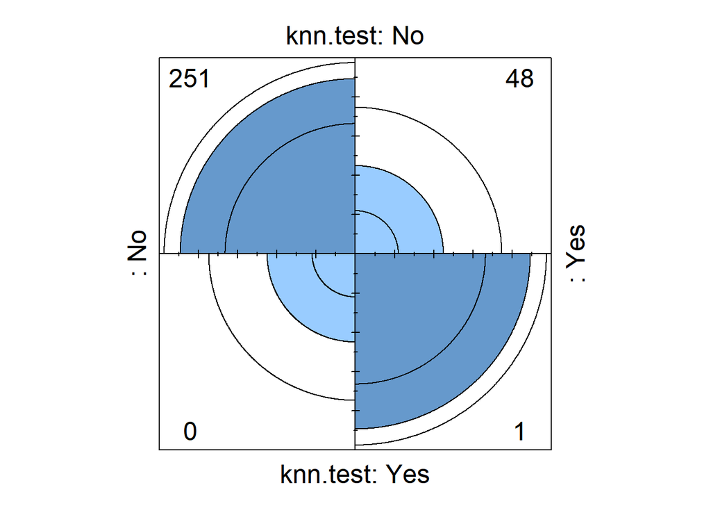

#### *KNN Weighted*

```
## Confusion Matrix and Statistics
##
##
## prediction  No Yes
##        No  251  47
##        Yes   0   2
##
##                Accuracy : 0.8433
##                  95% CI : (0.7972, 0.8826)
##     No Information Rate : 0.8367
##     P-Value [Acc > NIR] : 0.4139
##
##                   Kappa : 0.0665
##  Mcnemar's Test P-Value : 1.949e-11
##
##             Sensitivity : 1.00000
##             Specificity : 0.04082
##          Pos Pred Value : 0.84228
##          Neg Pred Value : 1.00000
##              Prevalence : 0.83667
##          Detection Rate : 0.83667
##    Detection Prevalence : 0.99333
##       Balanced Accuracy : 0.52041
##
##        'Positive' Class : No
##
```

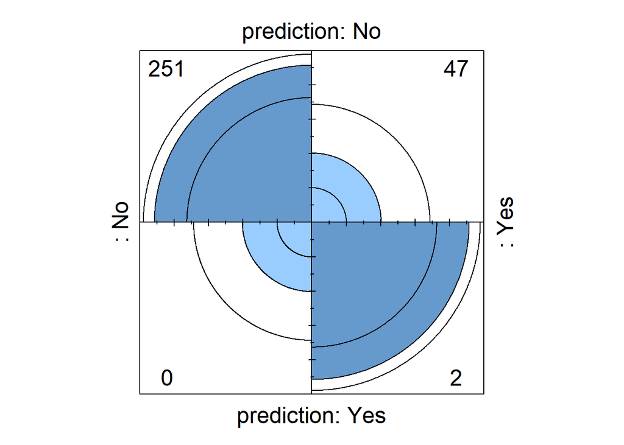

#### *Logistic_Regression*

The following model is logistic regression the test and training set for all the fields. For logistic regression to work, the data was formatted to numeric data and setup with a prediction interval in which we converted a probability. In this model, we predicted at an 87% rate.

```
##
## Call:
## glm(formula = emp_train$Attrition ~ ., family = binomial, data = emp_train[,
##     c(cols.CatGLM)])
##
## Deviance Residuals:
##     Min       1Q   Median       3Q      Max
## -1.5831  -0.4893  -0.2395  -0.0824   3.2351
##
## Coefficients: (3 not defined because of singularities)
##                                    Estimate Std. Error z value Pr(>|z|)
## (Intercept)                      -1.254e+01  6.957e+02  -0.018 0.985624
## ID                                9.763e-05  2.958e-04   0.330 0.741323
## Age                              -1.917e-02  1.523e-02  -1.259 0.208184
## BusinessTravelTravel_Frequently   1.858e+00  4.663e-01   3.985 6.74e-05
## BusinessTravelTravel_Rarely       9.574e-01  4.292e-01   2.231 0.025704
## DailyRate                        -3.949e-04  2.497e-04  -1.581 0.113774
## DepartmentResearch & Development  1.388e+01  6.957e+02   0.020 0.984083
## DepartmentSales                   1.256e+01  6.957e+02   0.018 0.985594
## DistanceFromHome                  4.361e-02  1.213e-02   3.595 0.000324
## Education                         2.211e-02  1.009e-01   0.219 0.826621
## EducationFieldLife Sciences      -3.611e-02  1.154e+00  -0.031 0.975033
## EducationFieldMarketing           2.371e-01  1.203e+00   0.197 0.843799
## EducationFieldMedical            -1.310e-01  1.157e+00  -0.113 0.909880
## EducationFieldOther              -4.750e-01  1.216e+00  -0.391 0.696003
## EducationFieldTechnical Degree    8.451e-01  1.165e+00   0.725 0.468361
## EmployeeCount                            NA         NA      NA       NA
## EmployeeNumber                   -2.082e-05  1.704e-04  -0.122 0.902721
## EnvironmentSatisfaction          -4.711e-01  9.506e-02  -4.956 7.19e-07
## GenderMale                        3.846e-01  2.092e-01   1.838 0.066038
## HourlyRate                        6.008e-03  5.046e-03   1.191 0.233741
## JobInvolvement                   -6.303e-01  1.392e-01  -4.526 6.00e-06
## JobLevel                         -3.281e-01  3.454e-01  -0.950 0.342197
## JobRoleHuman Resources            1.484e+01  6.957e+02   0.021 0.982979
## JobRoleLaboratory Technician      1.284e+00  5.151e-01   2.492 0.012707
## JobRoleManager                    1.561e-01  9.205e-01   0.170 0.865340
## JobRoleManufacturing Director    -7.803e-02  5.739e-01  -0.136 0.891857
## JobRoleResearch Director         -2.824e+00  1.339e+00  -2.109 0.034961
## JobRoleResearch Scientist         9.597e-02  5.307e-01   0.181 0.856513
## JobRoleSales Executive            2.046e+00  1.376e+00   1.486 0.137207
```

[output cut: 67 more lines]

```
## WorkLifeBalance                  ***
## YearsAtCompany                   *
## YearsInCurrentRole               **
## YearsSinceLastPromotion          ***
## YearsWithCurrManager             *
## ---
## Signif. codes:  0 '***' 0.001 '**' 0.01 '*' 0.05 '.' 0.1 ' ' 1
##
## (Dispersion parameter for binomial family taken to be 1)
##
##     Null deviance: 1031.48  on 1169  degrees of freedom
## Residual deviance:  674.24  on 1123  degrees of freedom
## AIC: 768.24
##
## Number of Fisher Scoring iterations: 15
```

```
##     Yes
## No    0
## Yes   1
```

```
## Confusion Matrix and Statistics
##
##      true
## pred   No Yes
##   No  244  32
##   Yes   7  17
##
##                Accuracy : 0.87
##                  95% CI : (0.8266, 0.9059)
##     No Information Rate : 0.8367
##     P-Value [Acc > NIR] : 0.0658297
##
##                   Kappa : 0.4015
##  Mcnemar's Test P-Value : 0.0001215
##
##             Sensitivity : 0.9721
##             Specificity : 0.3469
##          Pos Pred Value : 0.8841
##          Neg Pred Value : 0.7083
##              Prevalence : 0.8367
##          Detection Rate : 0.8133
##    Detection Prevalence : 0.9200
##       Balanced Accuracy : 0.6595
##
##        'Positive' Class : No
##
```

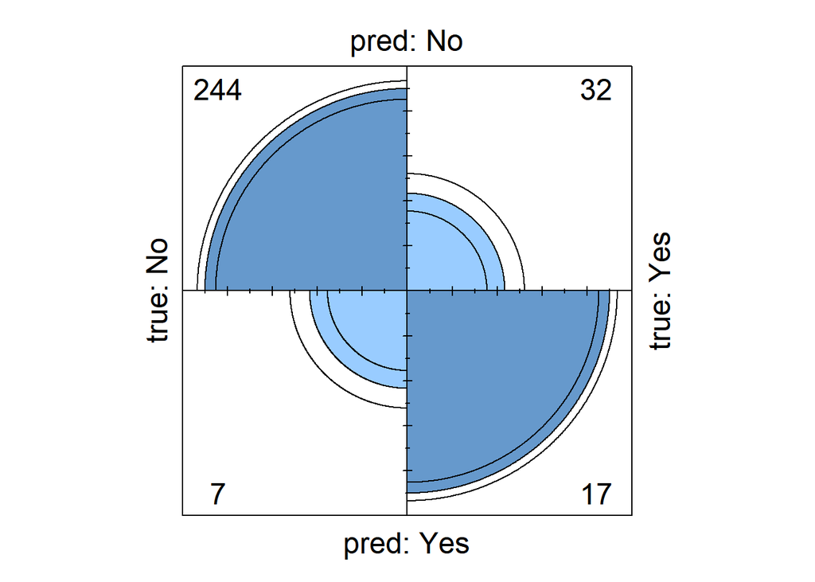

| ID | Prediction |
| --- | --- |
| 1171 | No |
| 1172 | No |
| 1173 | No |
| 1174 | No |
| 1175 | No |
| 1176 | No |
| 1177 | No |
| 1178 | No |
| 1179 | No |
| 1180 | No |

[output cut: 290 more lines]

##### Summary Explanation:

```
## Confusion Matrix and Statistics
##
##      true
## pred   No Yes
##   No  244  32
##   Yes   7  17
##
##                Accuracy : 0.87
##                  95% CI : (0.8266, 0.9059)
##     No Information Rate : 0.8367
##     P-Value [Acc > NIR] : 0.0658297
##
##                   Kappa : 0.4015
##  Mcnemar's Test P-Value : 0.0001215
##
##             Sensitivity : 0.9721
##             Specificity : 0.3469
##          Pos Pred Value : 0.8841
##          Neg Pred Value : 0.7083
##              Prevalence : 0.8367
##          Detection Rate : 0.8133
##    Detection Prevalence : 0.9200
##       Balanced Accuracy : 0.6595
##
##        'Positive' Class : No
##
```

```
## Confusion Matrix and Statistics
##
##
## knn.test  No Yes
##      No  251  48
##      Yes   0   1
##
##                Accuracy : 0.84
##                  95% CI : (0.7935, 0.8796)
##     No Information Rate : 0.8367
##     P-Value [Acc > NIR] : 0.4758
##
##                   Kappa : 0.0337
##  Mcnemar's Test P-Value : 1.17e-11
##
##             Sensitivity : 1.00000
##             Specificity : 0.02041
##          Pos Pred Value : 0.83946
##          Neg Pred Value : 1.00000
##              Prevalence : 0.83667
##          Detection Rate : 0.83667
##    Detection Prevalence : 0.99667
##       Balanced Accuracy : 0.51020
##
##        'Positive' Class : No
##
```

```
## Confusion Matrix and Statistics
##
##
## prediction  No Yes
##        No  251  47
##        Yes   0   2
##
##                Accuracy : 0.8433
##                  95% CI : (0.7972, 0.8826)
##     No Information Rate : 0.8367
##     P-Value [Acc > NIR] : 0.4139
##
##                   Kappa : 0.0665
##  Mcnemar's Test P-Value : 1.949e-11
##
##             Sensitivity : 1.00000
##             Specificity : 0.04082
##          Pos Pred Value : 0.84228
##          Neg Pred Value : 1.00000
##              Prevalence : 0.83667
##          Detection Rate : 0.83667
##    Detection Prevalence : 0.99333
##       Balanced Accuracy : 0.52041
##
##        'Positive' Class : No
##
```

|  | Type | Accuracy | Sensitivity | Specificity |
| --- | --- | --- | --- | --- |
| 1 | LogRegOnly | 0.8700000 | 0.9721116 | 0.3469388 |
| 3 | kWeighted | 0.8433333 | 1.0000000 | 0.0408163 |
| 2 | kNN | 0.8400000 | 1.0000000 | 0.0204082 |

##### Appendix

- YouTube link: https://youtu.be/oCrYuL4jm-g
- Github link: https://github.com/joshyi67/SMU-MSDS-Homework/tree/master/Case%20Study%202